# Homework 3: Health Expenditures

STA 651 – Generalized Linear Models

Richel Ohenewaa Attafuah

## Overview

You will model **individual‑level medical charges** using a GLiM of your choice. You must determine an appropriate **family**, **link**, and **model structure** based on exploratory analysis and justification.

**Dataset:** Kaggle “Medical Cost Personal Dataset” (public mirror)  
URL for direct load:  
`https://raw.githubusercontent.com/stedy/Machine-Learning-with-R-datasets/master/insurance.csv`

**Variables:** `age`, `sex`, `bmi`, `children`, `smoker`, `region`, `charges`

**Grading (50 points)**

## Setup & Data

```r
# install.packages(c("dplyr","ggplot2","readr","janitor"))
library(dplyr)
library(ggplot2)
library(readr)
library(janitor)

url <- "https://raw.githubusercontent.com/stedy/Machine-Learning-with-R-datasets/master/insurance.csv"
ins <- readr::read_csv(url) |> janitor::clean_names() |>
  mutate(across(c(sex, smoker, region), factor))

glimpse(ins)
```

```
## Rows: 1,338
## Columns: 7
## $ age      <dbl> 19, 18, 28, 33, 32, 31, 46, 37, 37, 60, 25, 62, 23, 56, 27, 1…
## $ sex      <fct> female, male, male, male, male, female, female, female, male,…
## $ bmi      <dbl> 27.900, 33.770, 33.000, 22.705, 28.880, 25.740, 33.440, 27.74…
## $ children <dbl> 0, 1, 3, 0, 0, 0, 1, 3, 2, 0, 0, 0, 0, 0, 0, 1, 1, 0, 0, 0, 0…
## $ smoker   <fct> yes, no, no, no, no, no, no, no, no, no, no, yes, no, no, yes…
## $ region   <fct> southwest, southeast, southeast, northwest, northwest, southe…
## $ charges  <dbl> 16884.924, 1725.552, 4449.462, 21984.471, 3866.855, 3756.622,…
```

```r
head(ins, 10)
```

| age | sex | bmi | children | smoker | region | charges |
| --- | --- | --- | --- | --- | --- | --- |
| 19 | female | 27.900 | 0 | yes | southwest | 16884.924 |
| 18 | male | 33.770 | 1 | no | southeast | 1725.552 |
| 28 | male | 33.000 | 3 | no | southeast | 4449.462 |
| 33 | male | 22.705 | 0 | no | northwest | 21984.471 |
| 32 | male | 28.880 | 0 | no | northwest | 3866.855 |
| 31 | female | 25.740 | 0 | no | southeast | 3756.622 |
| 46 | female | 33.440 | 1 | no | southeast | 8240.590 |
| 37 | female | 27.740 | 3 | no | northwest | 7281.506 |
| 37 | male | 29.830 | 2 | no | northeast | 6406.411 |
| 60 | female | 25.840 | 0 | no | northwest | 28923.137 |

## 1. EDA (5 pts)

Provide EDA (e.g., histograms/density of `charges`) and propose at least **three plausible** modeling strategies and discuss pros/cons.

```r
# basic structure
dim(ins)
```

```
## [1] 1338    7
```

```r
summary(ins)
```

```
##       age            sex           bmi           children     smoker
##  Min.   :18.00   female:662   Min.   :15.96   Min.   :0.000   no :1064
##  1st Qu.:27.00   male  :676   1st Qu.:26.30   1st Qu.:0.000   yes: 274
##  Median :39.00                Median :30.40   Median :1.000
##  Mean   :39.21                Mean   :30.66   Mean   :1.095
##  3rd Qu.:51.00                3rd Qu.:34.69   3rd Qu.:2.000
##  Max.   :64.00                Max.   :53.13   Max.   :5.000
##        region       charges
##  northeast:324   Min.   : 1122
##  northwest:325   1st Qu.: 4740
##  southeast:364   Median : 9382
##  southwest:325   Mean   :13270
##                  3rd Qu.:16640
##                  Max.   :63770
```

```r
# missing values check
colSums(is.na(ins))
```

```
##      age      sex      bmi children   smoker   region  charges
##        0        0        0        0        0        0        0
```

```r
# check unique values for categoricals
ins %>%
  summarise(
    n_age = n_distinct(age),
    n_sex = n_distinct(sex),
    n_bmi = n_distinct(bmi),
    n_children = n_distinct(children),
    n_smoker = n_distinct(smoker),
    n_region = n_distinct(region)
  )
```

| n_age | n_sex | n_bmi | n_children | n_smoker | n_region |
| --- | --- | --- | --- | --- | --- |
| 47 | 2 | 548 | 6 | 2 | 4 |

```r
# quick tabulations
table(ins$sex)
```

```
##
## female   male
##    662    676
```

```r
table(ins$smoker)
```

```
##
##   no  yes
## 1064  274
```

```r
table(ins$region)
```

```
##
## northeast northwest southeast southwest
##       324       325       364       325
```

```r
table(ins$children)
```

```
##
##   0   1   2   3   4   5
## 574 324 240 157  25  18
```

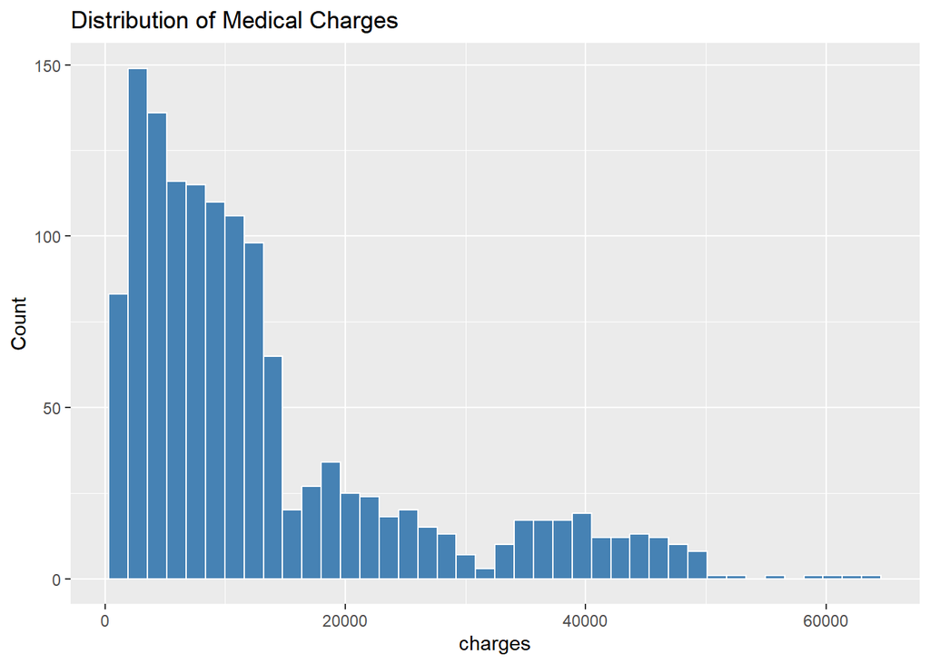

```r
# Histogram of charges
ggplot(ins, aes(x = charges)) +
  geom_histogram(bins = 40, fill = "steelblue", color = "white") +
  labs(title = "Distribution of Medical Charges", x = "charges", y = "Count")
```

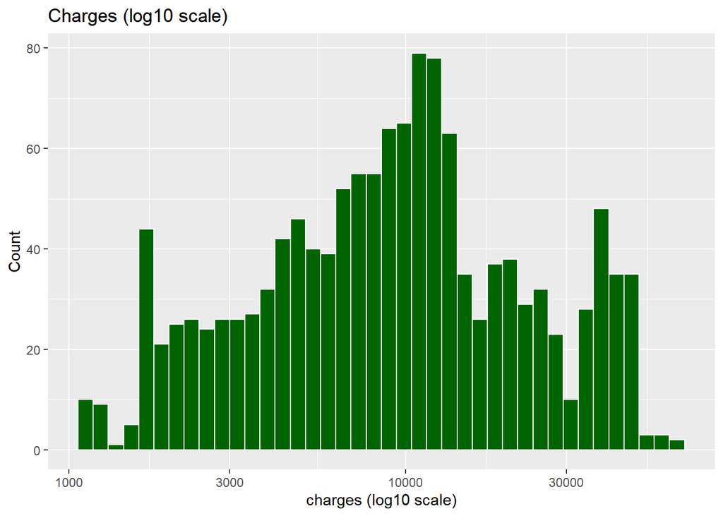

```r
# Histogram on log scale
ggplot(ins, aes(x = charges)) +
  geom_histogram(bins = 40, fill = "darkgreen", color = "white") +
  scale_x_log10() +
  labs(title = "Charges (log10 scale)", x = "charges (log10 scale)", y = "Count")
```

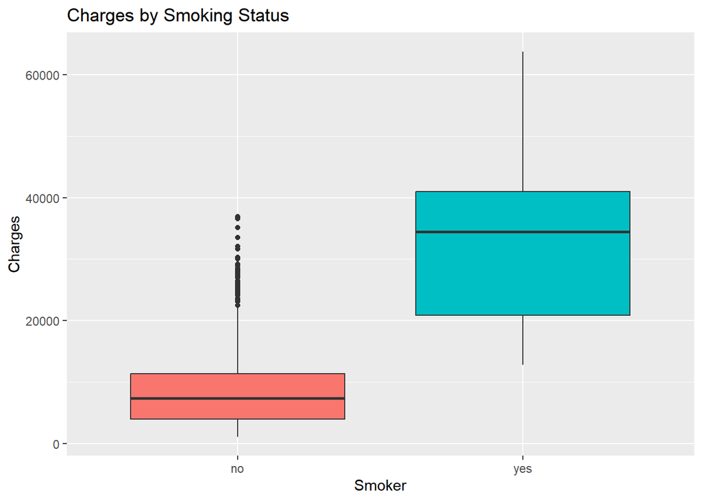

```r
# Boxplot by smoker
ggplot(ins, aes(x = smoker, y = charges, fill = smoker)) +
  geom_boxplot() +
  labs(title = "Charges by Smoking Status", x = "Smoker", y = "Charges") +
  theme(legend.position = "none")
```

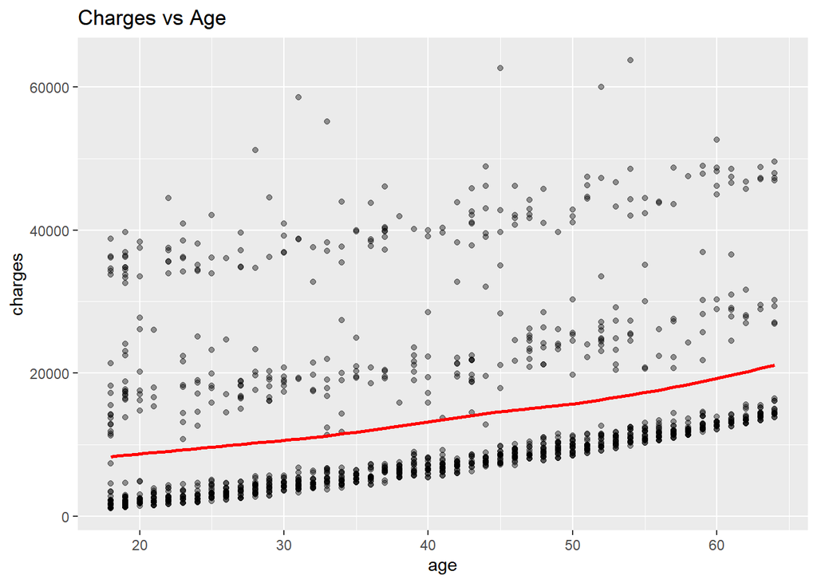

```r
# Age vs charges and log(charges)
ggplot(ins, aes(x = age, y = charges)) +
  geom_point(alpha = 0.4) +
  geom_smooth(method = "loess", se = FALSE, color = "red") +
  labs(title = "Charges vs Age")
```

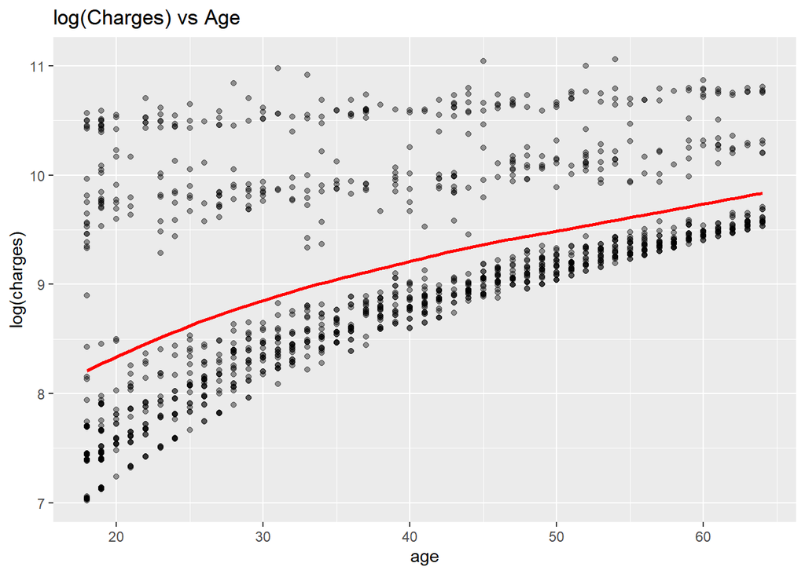

```r
ggplot(ins, aes(x = age, y = log(charges))) +
  geom_point(alpha = 0.4) +
  geom_smooth(method = "loess", se = FALSE, color = "red") +
  labs(title = "log(Charges) vs Age")
```

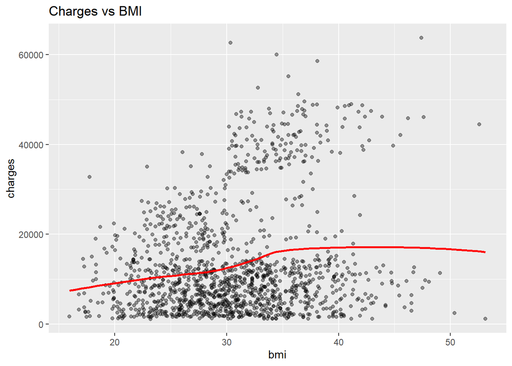

```r
# BMI vs charges
ggplot(ins, aes(x = bmi, y = charges)) +
  geom_point(alpha = 0.4) +
  geom_smooth(method = "loess", se = FALSE, color = "red") +
  labs(title = "Charges vs BMI")
```

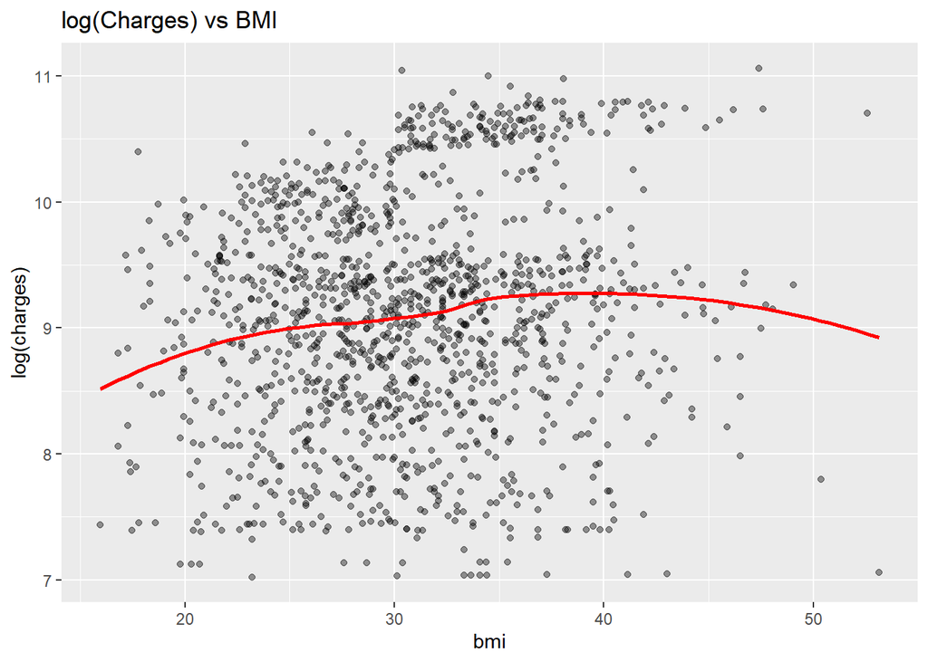

```r
ggplot(ins, aes(x = bmi, y = log(charges))) +
  geom_point(alpha = 0.4) +
  geom_smooth(method = "loess", se = FALSE, color = "red") +
  labs(title = "log(Charges) vs BMI")
```

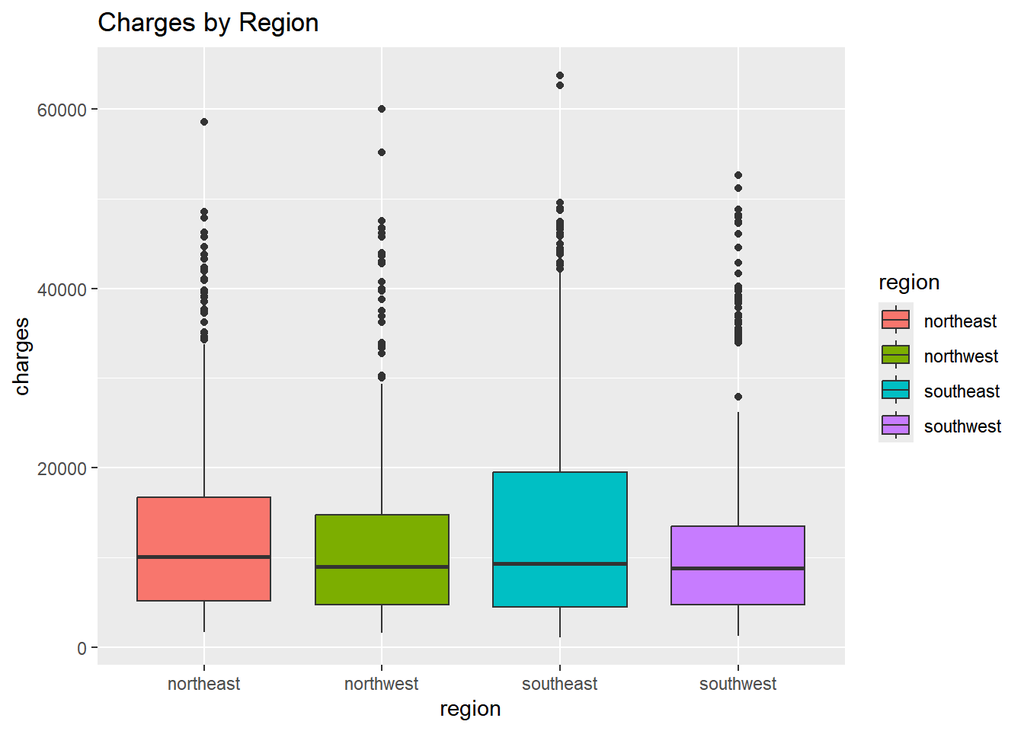

```r
# Charges by region and sex
ggplot(ins, aes(x = region, y = charges, fill = region)) +
  geom_boxplot() +
  labs(title = "Charges by Region")
```

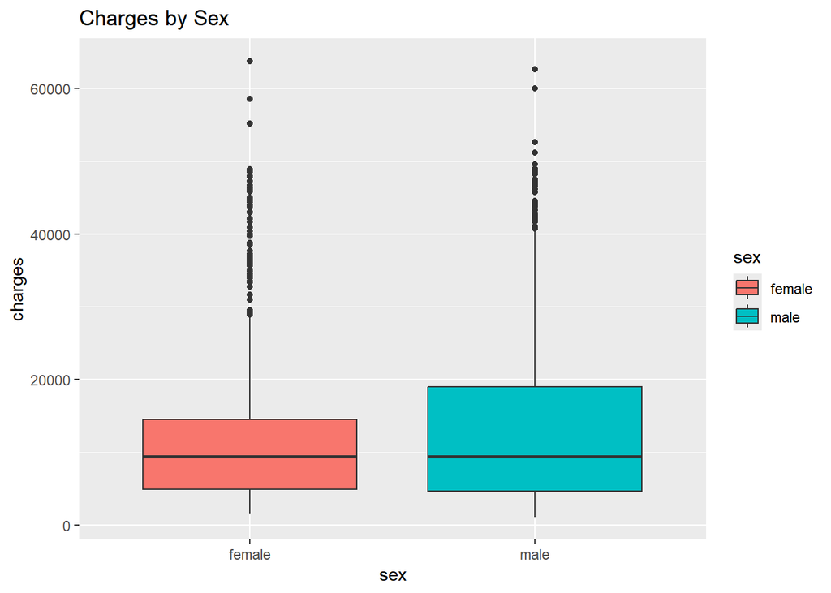

```r
ggplot(ins, aes(x = sex, y = charges, fill = sex)) +
  geom_boxplot() +
  labs(title = "Charges by Sex")
```

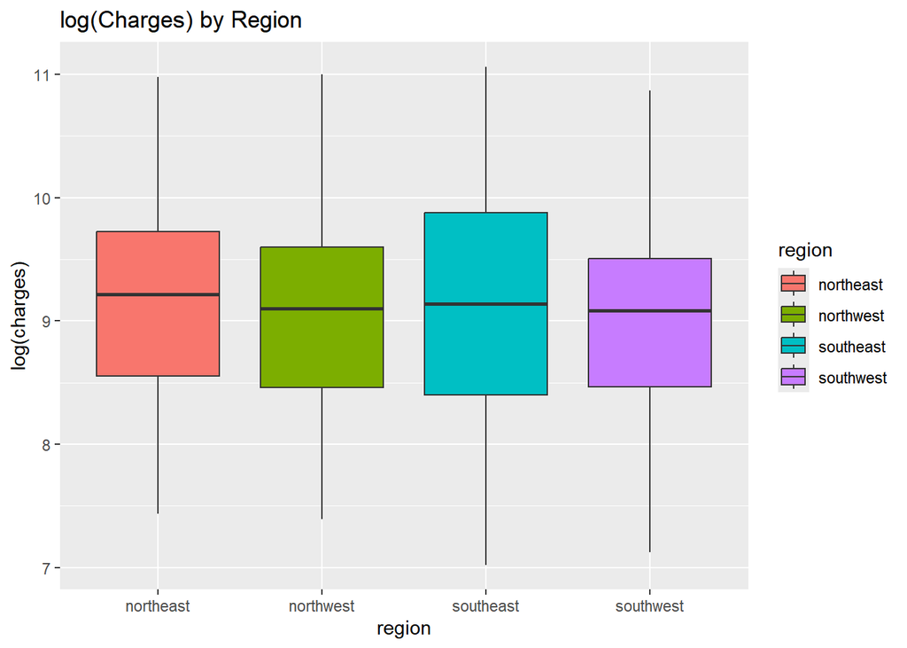

```r
# Charges by region and sex
ggplot(ins, aes(x = region, y = log(charges), fill = region)) +
  geom_boxplot() +
  labs(title = "log(Charges) by Region")
```

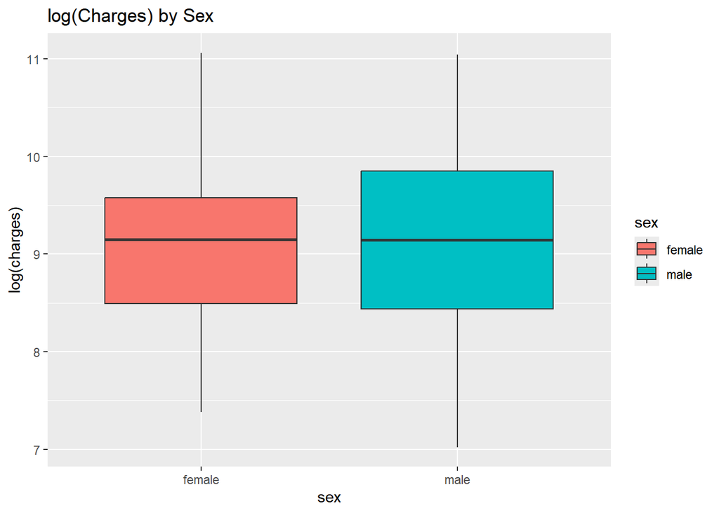

```r
ggplot(ins, aes(x = sex, y = log(charges), fill = sex)) +
  geom_boxplot() +
  labs(title = "log(Charges) by Sex")
```

## Proposed GLM modeling strategies

Based on the exploratory analysis, the outcome variable `charges` is - strictly positive, - strongly right-skewed, - shows larger variability for larger charges (especially among smokers), - and becomes more regular and almost linear in the predictors after a log transformation.

These features suggest using GLM-type models with a log scale. The following three models are proposed, listed in order of expected suitability for this dataset.

### 1. Gamma GLM with log link

**Reasoning from EDA:** charges are positive and right-skewed, and variability increases with the mean. This is the typical setting for a Gamma distribution with a log link.

**Pros** - Designed for positive, right-skewed cost/charge data. - Log link gives multiplicative/percentage interpretation of predictors. - Handles heteroscedasticity naturally (var ∝ mean²). - Consistent with the clear separation between smokers and non-smokers.

**Cons** - Can be sensitive to very extreme observations (very high charges). - Requires correct specification of the mean–variance relationship. - Diagnostics (deviance, dispersion) are less familiar than for linear models.

### 2. Log-normal regression (Gaussian on log(charges))

**Reasoning from EDA:** the histogram of `charges` was highly skewed, but on the log scale the distribution became more symmetric and the relationships with age and BMI became closer to linear.

**Pros** - Very simple to explain and to diagnose (residual plots, normality on log scale). - Log transformation stabilizes variance and makes effects additive on the log scale. - Coefficients can be interpreted approximately as percentage changes after exponentiation.

**Cons** - Works on a transformed scale; predictions on the original scale need back-transformation (and possibly bias correction). - Assumes normality of log(charges), not the GLM mean–variance structure. - Still affected by extreme high-cost patients, even on the log scale.

### 3. Inverse Gaussian GLM with log link

**Reasoning from EDA:** there is a small group of very high charges (long right tail). An inverse Gaussian with log link is another GLM for positive, continuous outcomes that allows heavier tails than the Gamma.

**Pros** - Appropriate for strictly positive, continuous data with a long right tail. - Same log-link interpretation as the Gamma (multiplicative effects). - Useful as a robustness/sensitivity model to check conclusions from the Gamma model.

**Cons** - More complex distribution; diagnostics and interpretation are less familiar. - Can be numerically a bit less stable than the Gamma model. - If the tail is not truly that heavy, it may not improve fit over Gamma.

**Summary:**  
Because the data are positive and right-skewed, a **Gamma GLM with log link** is the primary candidate. A **log-normal (Gaussian on log response)** model is kept as a simpler, easy-to-explain alternative supported by the log-scale plots. An **inverse Gaussian GLM with log link** is proposed as a third, more flexible option to check sensitivity to the heavy right tail observed in the EDA.

## 2. Model Formulation (10 pts)

Define your **response** and choose a **family** and **link**. Write the linear predictor and interpret at least one coefficient on the **original scale**.

```r
gamma_mod <- glm(
  charges ~ age + bmi + children + sex + smoker + region ,
  family = Gamma(link = "log"),
  data = ins
)

#model summary
summary(gamma_mod)
```

```
##
## Call:
## glm(formula = charges ~ age + bmi + children + sex + smoker +
##     region, family = Gamma(link = "log"), data = ins)
##
## Coefficients:
##                  Estimate Std. Error t value Pr(>|t|)
## (Intercept)      7.386342   0.111350  66.334  < 2e-16 ***
## age              0.028638   0.001341  21.351  < 2e-16 ***
## bmi              0.014123   0.003224   4.381 1.28e-05 ***
## children         0.084173   0.015534   5.419 7.12e-08 ***
## sexmale         -0.057079   0.037531  -1.521  0.12854
## smokeryes        1.500330   0.046572  32.215  < 2e-16 ***
## regionnorthwest -0.057875   0.053687  -1.078  0.28123
## regionsoutheast -0.141637   0.053960  -2.625  0.00877 **
## regionsouthwest -0.145484   0.053874  -2.700  0.00701 **
## ---
## Signif. codes:  0 '***' 0.001 '**' 0.01 '*' 0.05 '.' 0.1 ' ' 1
##
## (Dispersion parameter for Gamma family taken to be 0.4669548)
##
##     Null deviance: 1056.04  on 1337  degrees of freedom
## Residual deviance:  337.73  on 1329  degrees of freedom
## AIC: 26379
##
## Number of Fisher Scoring iterations: 7
```

### Coefficient interpretation (Gamma model with log link)

The coefficient for `smokeryes` is 1.5003.  
Because the model uses a log link, exponentiating this value gives:

$$\exp(1.5003) = 4.48$$

This means that, on average, and holding other factors constant, smokers are expected to have medical charges about 4.5 times higher than non-smokers.

## 3. Estimation & Inference (10 pts)

Fit your primary model, provide **CIs**, and test at least one **interaction** or composite hypothesis (e.g., `smoker × bmi`).

```r
gamma_int <- glm(
  charges ~ age + bmi * smoker + children + sex + region,
  family = Gamma(link = "log"),
  data = ins
)

summary(gamma_int)
```

```
##
## Call:
## glm(formula = charges ~ age + bmi * smoker + children + sex +
##     region, family = Gamma(link = "log"), data = ins)
##
## Coefficients:
##                  Estimate Std. Error t value Pr(>|t|)
## (Intercept)      7.694648   0.120208  64.011  < 2e-16 ***
## age              0.029027   0.001321  21.966  < 2e-16 ***
## bmi              0.003868   0.003555   1.088  0.27678
## smokeryes        0.038777   0.228897   0.169  0.86550
## children         0.085211   0.015301   5.569 3.09e-08 ***
## sexmale         -0.068122   0.037011  -1.841  0.06591 .
## regionnorthwest -0.066097   0.052890  -1.250  0.21163
## regionsoutheast -0.153198   0.053153  -2.882  0.00401 **
## regionsouthwest -0.154935   0.053079  -2.919  0.00357 **
## bmi:smokeryes    0.047002   0.007311   6.429 1.79e-10 ***
## ---
## Signif. codes:  0 '***' 0.001 '**' 0.01 '*' 0.05 '.' 0.1 ' ' 1
##
## (Dispersion parameter for Gamma family taken to be 0.4529633)
##
##     Null deviance: 1056.04  on 1337  degrees of freedom
## Residual deviance:  320.28  on 1328  degrees of freedom
## AIC: 26307
##
## Number of Fisher Scoring iterations: 7
```

```r
# 95% Wald Confidence Intervals (multiplicative effects)
exp_coef <- exp(cbind(
  Estimate = coef(gamma_int),
  confint.default(gamma_int)
))

round(exp_coef, 3)
```

```
##                 Estimate    2.5 %   97.5 %
## (Intercept)     2196.560 1735.489 2780.123
## age                1.029    1.027    1.032
## bmi                1.004    0.997    1.011
## smokeryes          1.040    0.664    1.628
## children           1.089    1.057    1.122
## sexmale            0.934    0.869    1.004
## regionnorthwest    0.936    0.844    1.038
## regionsoutheast    0.858    0.773    0.952
## regionsouthwest    0.856    0.772    0.950
## bmi:smokeryes      1.048    1.033    1.063
```

## 4. Model Comparison (10 pts)

Compare to at least **two alternatives** specification. Use appropriate criteria (AIC/BIC, deviance, residual analysis).

```r
# Fit models ---

# Log-normal model (Gaussian on log(charges))
ln_mod <- lm(log(charges) ~ age + bmi + children + sex + smoker + region, data = ins)

# Gamma GLM
gamma_mod <- glm(charges ~ age + bmi + children + sex + smoker + region,
                 family = Gamma(link = "log"),
                 data = ins)

# Inverse Gaussian GLM
inv_mod <- glm(charges ~ age + bmi + children + sex + smoker + region,
               family = inverse.gaussian(link = "log"),
               data = ins)

# Collect key fit statistics ---

model_comp <- data.frame(
  Model = c("Log-normal (Gaussian on log Y)",
            "Gamma (log link)",
            "Inverse Gaussian (log link)"),
  AIC = c(AIC(ln_mod), AIC(gamma_mod), AIC(inv_mod)),
  BIC = c(BIC(ln_mod), BIC(gamma_mod), BIC(inv_mod)),
  Residual_Deviance = c(NA, deviance(gamma_mod), deviance(inv_mod)),  # Deviance not defined for lm
  Residual_SE_or_Dispersion = c(
    sigma(ln_mod),   # residual standard error for lm
    summary(gamma_mod)$dispersion,
    summary(inv_mod)$dispersion
  )
)

knitr::kable(model_comp, digits = 3,
             caption = "Model comparison based on AIC, BIC, and residual measures")
```

Model comparison based on AIC, BIC, and residual measures

| Model | AIC | BIC | Residual_Deviance | Residual_SE_or_Dispersion |
| --- | --- | --- | --- | --- |
| Log-normal (Gaussian on log Y) | 1637.033 | 1689.023 | NA | 0.444 |
| Gamma (log link) | 26379.243 | 26431.233 | 337.727 | 0.467 |
| Inverse Gaussian (log link) | 26812.577 | 26864.566 | 0.054 | 0.000 |

### Model comparison and selection

All three candidate models were fitted using the same predictors and compared using AIC, BIC, residual deviance, and residual dispersion.  
The log-normal regression achieved the lowest AIC and BIC, indicating the best balance between goodness-of-fit and model complexity. Its residual standard error (0.44 on the log scale) suggests homoscedastic and well-behaved residuals.

The Gamma GLM with log link also provided a good fit, with residual deviance (≈338) and dispersion (≈0.47) consistent with the expected variance–mean relationship. This confirms that the Gamma distribution is theoretically suitable for strictly positive, right-skewed cost data.

The Inverse Gaussian model exhibited near-zero dispersion and very low deviance, indicating numerical instability and a poor match to the data distribution.

## 5. Diagnostics (10 pts)

Provide residual diagnostics **appropriate to your family**, check influential cases, and comment on **variance function** assumptions.

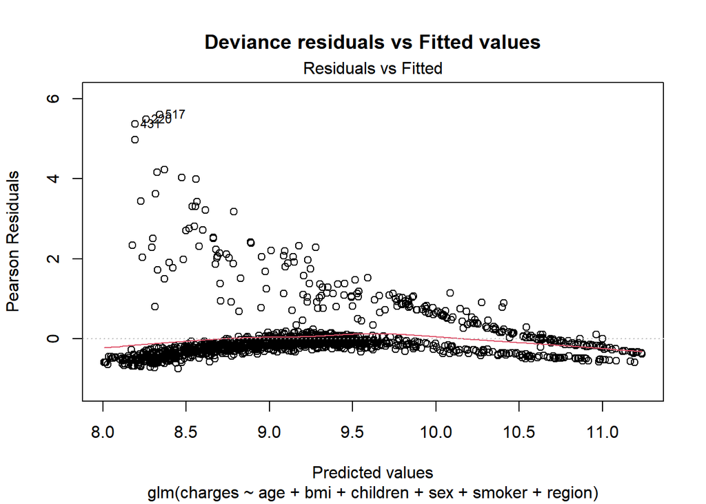

```r
# Refit the final model for clarity
gamma_mod <- glm(
  charges ~ age + bmi + children + sex + smoker + region,
  family = Gamma(link = "log"),
  data = ins
)

# 1. Deviance residuals vs fitted values
plot(gamma_mod, which = 1, main = "Deviance residuals vs Fitted values")
```

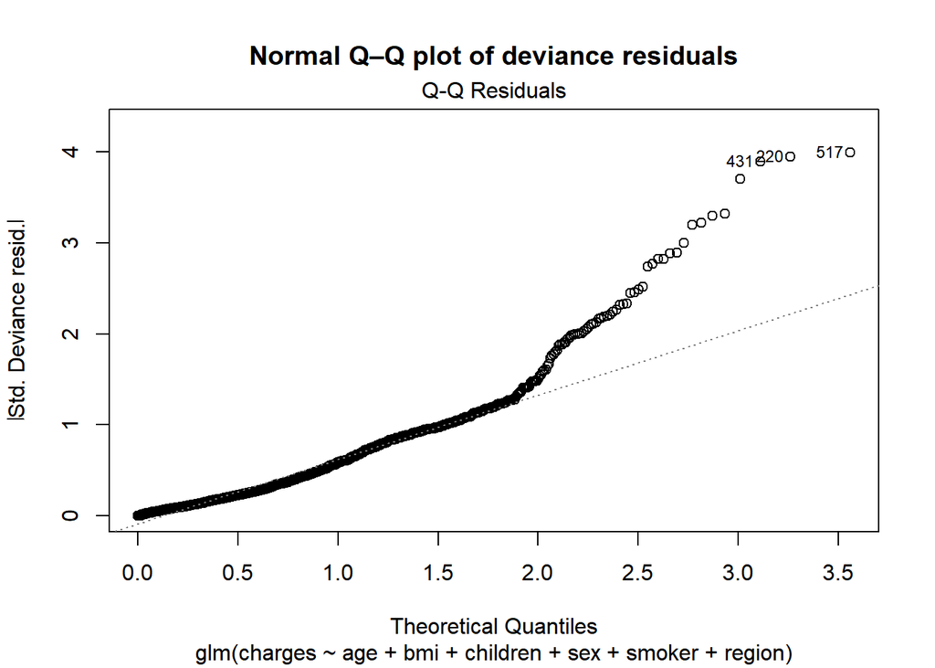

```r
# 2. Normal Q–Q plot of deviance residuals
plot(gamma_mod, which = 2, main = "Normal Q–Q plot of deviance residuals")
```

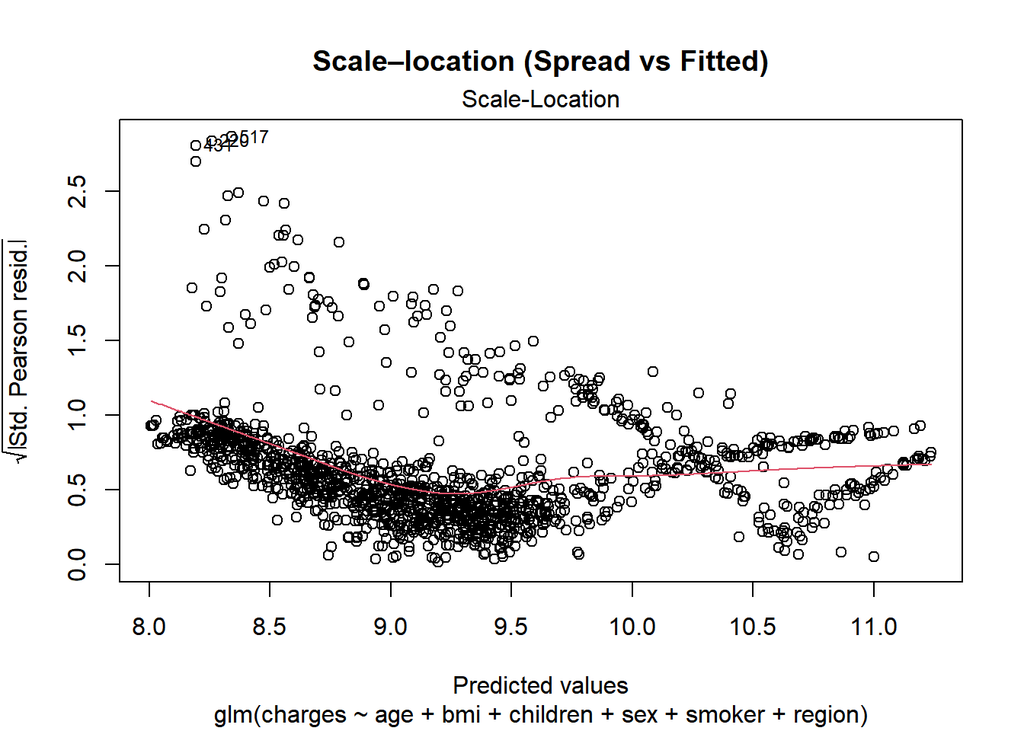

```r
# 3. Scale-location plot
plot(gamma_mod, which = 3, main = "Scale–location (Spread vs Fitted)")
```

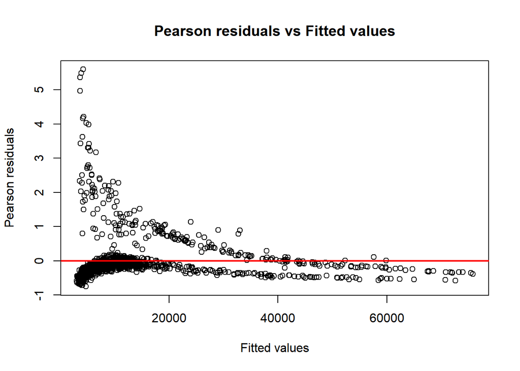

```r
# 4. Residuals vs fitted (Pearson)
plot(fitted(gamma_mod), resid(gamma_mod, type = "pearson"),
     xlab = "Fitted values",
     ylab = "Pearson residuals",
     main = "Pearson residuals vs Fitted values")
abline(h = 0, col = "red", lwd = 2)
```

### Variance function assumption (Gamma family)

In a Gamma GLM with a log link, we assume that the variance of the response increases with the square of the mean:

$$Var(Y_i) = \phi \mu_i^2$$

## 6. Interpretation & Communication (5 pts)

Summarize practical implications for **premium pricing** or **risk stratification**, including limitations.

### Practical implications for premium pricing and risk stratification

The Gamma GLM helps estimate expected medical costs for individuals based on their personal characteristics. In practice, this kind of model can guide how insurers set premium levels and categorize risk among policyholders.

From the model results, age, BMI, and especially smoking status were strong predictors of higher medical charges. For example, smokers had much higher expected costs than non-smokers, even after adjusting for age and BMI. This means that in a real insurance setting, smokers or individuals with high BMI would likely fall into higher-premium or high-risk categories, while younger, non-smoking individuals would be assigned lower premiums.

**However, there are limitations.** - The dataset does not include important behavioral or medical history variables (like pre-existing conditions, lifestyle, or access to care). - The model assumes a stable relationship between predictors and costs over time, which may not hold if healthcare prices or policies change. - It also does not account for random effects (such as individual-level variability or provider-level differences), which might lead to over- or under-pricing for some customers.

**In summary**, the Gamma model is a useful starting point for fairer and more data-driven premium pricing, but real-world applications should combine it with additional data, regular model updates, and ethical guidelines to avoid unfair discrimination in pricing.